# conceptos básicos

[figure not shown]

Profesora Carolina Luque

**Resultado de aprendizaje:** Analiza datos de diversa índole mediante técnicas de estadística descriptiva y probabilidad.

**Hito 1:** Análisis exploratorio de datos.

**Temas:**

- Población y muestra
- Estadístico y parámetro
- Tipos y clasificación de variables

# **Conceptos básicos**

## **Estadística y probabilidad**

La **estadística** es una ciencia que se ocupa de los métodos y las técnicas para **analizar conjuntos de datos**, con el fin de **tomar decisiones** racionales bajo **incertidumbre**, es decir, bajo un estado de información incompleta.

*"Una empresa de retail lanza una nueva campaña de marketing digital. Tiene algunos datos sobre campañas anteriores que han funcionado. No obstante, hay muchos factores desconocidos, como las tendencias actuales del consumidor y la efectividad de nuevos canales de marketing."*

La **probabilidad** es la rama de las matemáticas dedicada a la cuantificación de la incertidumbre.

La estadística se puede clasificar en:

- **Descriptiva**. El objeto es caracterizar y representar un grupo de datos utilizando métodos numéricos y gráficos para resumir la información contenida en ellos. Útil para *describir el estado actual de los datos*.
- **Inferencial**. El propósito es hacer afirmaciones sobre una población basándose en los datos de una muestra. Las extrapolaciones se apoyan en herramientas matemáticas y probabilísticas con el fin de cuantificar la incertidumbre de estas generalizaciones.

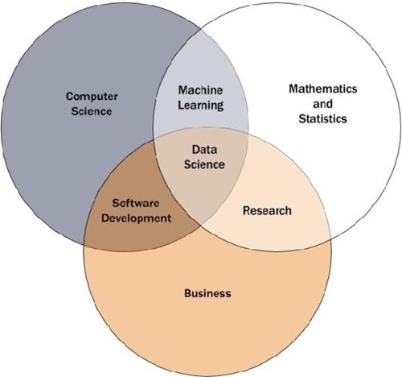

## **Población y muestra**

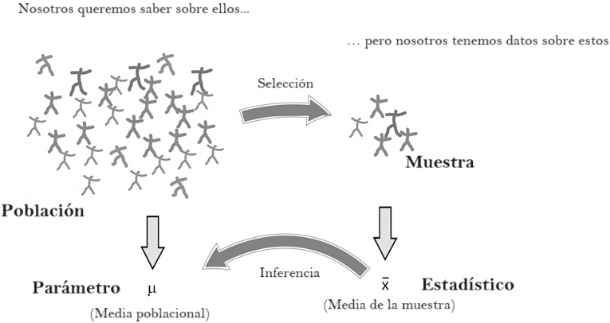

*Figura 2: Población y muestra. Tomado de Halswanter (2016).*

Una **población** es el conjunto de todos los individuos o mediciones que satisfacen las características propias del estudio.

- **Población finita**: el número de elementos que la conforma es finito. Por ejemplo, empleados de una empresa.
- **Población infinita**: el número de elementos que la forma es infinito (o es tan grande que se puede considerar como infinito). Por ejemplo, llamadas telefónicas a un centro de atención.

Una **muestra** es un subconjunto de individuos o mediciones de una población.

- **Muestra no probabilística**: la selección de los elementos de la muestra se realiza de forma subjetiva.
- **Muestra probabilística**: todos los elementos de la población tienen una posibilidad de hacer parte de la muestra.

### *Ejemplo*

*Población*. Las empresas multinacionales que tienen sede en Latino América.

*Muestra*. 20 empresas multinacionales con sede en al menos 3 países de Latino América.

Las cantidades que caracterizan la población y la muestra se denominan parámetro y estadístico, respectivamente.

- Un **estadístico** es una cantidad definida a partir de los valores de una variable que han sido observados en una muestra.
- Un **parámetro** es una cantidad definida sobre los valores de una variable observados en una población.

*"El objetivo es recopilar datos de una muestra para extraer información de ellos e inferir las características de la población."*

### **Selección de la muestra**

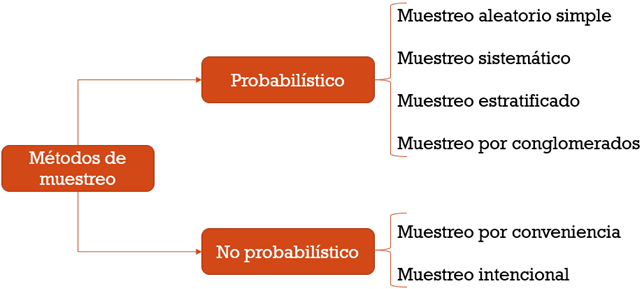

*Figura 3: Métodos de muestreo.*

Video [Tipos de métodos de muestreo](https://www.youtube.com/watch?v=pTuj57uXWlk)

#### **Métodos de muestreo probabilísticos**

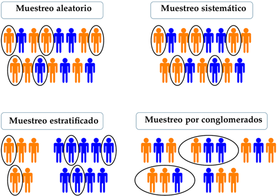

*Figura 4: Métodos de muestreo probabilístico.*

- **Muestreo aleatorio simple**. Todos los elementos del marco tienen la misma probabilidad de selección, y cada muestra de tamaño fijo tiene la misma probabilidad de selección que cualquier otra muestra de ese mismo tamaño. Los elementos se seleccionan al azar enlistándolos y utilizando números aleatorios.
- **Muestreo sistemático**. Se elige el primer elemento de forma aleatoria y luego, a partir de este se toma el $k$-ésimo elemento de forma iterativa. Suponga que tiene una lista de facturas, si $k=3$ esto significa que harán parte de la muestra la cuarta, séptima, decima, etc., factura. En otras palabras, la selección será de tres en tres contados a partir del primer elemento que se tomó al azar.
- **Muestreo estratificado**. Primero se subdividen los elementos del marco en subpoblaciones o estratos. Un estrato se define por alguna característica común, como el género, nivel socioeconómico, el año escolar, entre otros. Luego, se selecciona una muestra aleatoria simple dentro de cada uno de los estratos. Finalmente, estas muestras se combinan para tener una sola muestra.
- **Muestreo por conglomerados**. Los elementos están dispuestos en grupos. Los conglomerados suelen ser grupos naturales, como condados, distritos electorales, bloques de ciudades, escuelas, familias, entre otros. Para recolectar los datos, se toma una muestra aleatoria de conglomerados y se realiza un censo dentro de cada conglomerado seleccionado.

#### **Métodos de muestreo no probabilísticos**

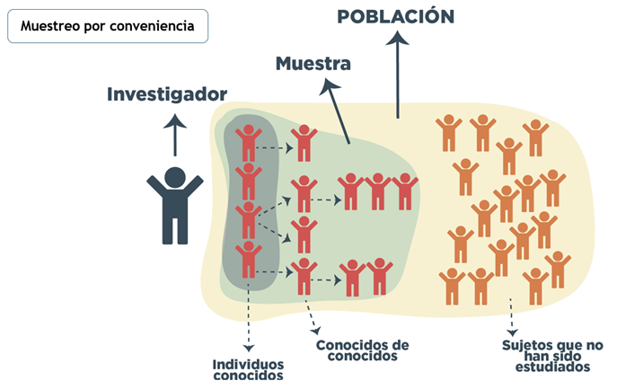

*Figura 5: Método de muestreo no probabilístico.*

- **Muestreo por conveniencia**. Se seleccionan los elementos de la población de acuerdo a la facilidad de acceso, disponibilidad de las personas, restricción de tiempo o cualquier otra especificación práctica. El investigador elige a los miembros solo por su proximidad y no considera si estos son realmente una muestra representativa de la población. Un ejemplo clásico de muestreo por conveniencia son las encuestas en línea que se envían solo a los contactos cercanos para que éstos las respondan y nos ayuden a difundirlas.
- **Muestreo intencional**. Técnica mediante la cual el investigador selecciona la muestra basado en su propio juicio. Aunque los elementos de la muestra se seleccionen de forma cuidadosa y bajo criterios previamente establecidos, esto no garantiza que los resultados se puedan generalizar a la población. Un ejemplo del muestreo intencional lo encontramos cuando los reporteros de noticias detienen (bajo un criterio particular) a personas en la calle para preguntarles sobre de un tema.

## **Práctica 1. Selección de muestras**

1. Explore la página [Spotify Music Data](https://www.datacamp.com/datalab/datasets/dataset-r-spotify-music). ¿Cuál es el **contexto** del conjunto de datos? ¿cuál es la **fuente** de los datos? ¿cuántas **variables** tiene el conjunto de datos?

Ahora, dirijase al aula virtual

2. Descargue el archivo **spotify.csv**
3. Decargue el archivo **02_prac1-selec-muestras.ipynb**
4. Guarde los archivos en su lugar de trabajo

## **Clasificación de variables**

Una **variable** es una característica observable o medible de un individuo que se expresa de acuerdo con con una escala de medición bien definida.

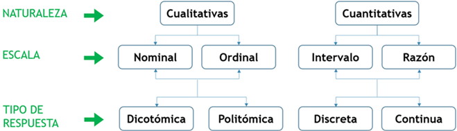

*Figura 6: Clasificación de las variables.*

### **Variables según su naturaleza**

La medición es un proceso mediante el cual se asignan valores cuantitativos o cualitativos a las características de los elementos objeto de estudio, de acuerdo con unas reglas claramente preestablecidas.

- Las **variables cualitativas** o categóricas son aquellas cuyos datos representan atributos o cualidades. Por ejemplo, género, estrato social, entre otras. Aunque el estrato social se suele representar por un número, en este caso el número no corresponde a una cantidad sino a una etiqueta.
- Las **variables cuantitativas** o numéricas son aquellas cuyos datos representan conteos o mediciones. Por ejemplo, número de hijos, tiempo de desplazamiento, entre otras.

### **Variables según su escala**

Una **escala de medición** es un esquema específico para asignar categorías o números con el objeto de designar valores de una variable.

- Las variables cualitativas en **escala nominal** son aquellas que clasifican las observaciones sin imponer orden o jerarquía entre categorías. Por ejemplo, el parentesco con el jefe del hogar donde las categorías son pareja, hijo u otro. El uso de billeteras electrónicas donde las categorías u opciones de clasificación son sí o no.
- Las variables cualitativas en **escala ordinal** son aquellas que clasifican las observaciones e imponen orden o jerarquía entre categorías. Por ejemplo, el último nivel educativo alcanzado donde las categorías son: primaria, secundaria, técnico, tecnólogo, universitario, especialización, maestría, doctorado. La categoría de afiliación en la caja de compensación donde las categorías son: A, B o C.
- Las variables cuantitativas en **escala de intervalo** son aquellas en las que el cero se interpreta como un punto de referencia. Bajo esta escala tiene sentido e interpretación la diferencia entre mediciones. Un ejemplo de una variable en escala de intervalo es la temperatura.
- Las variables cuantitativas en **escala de razón** son aquellas en las que el cero se interpreta como ausencia. Bajo esta escala tienen sentido e interpretación tanto la diferencia como el cociente entre mediciones. Un ejemplo de una variable en escala de razón es el costo de un artículo.

### **Variables según su tipo de respuesta**

- Las variables cualitativas **dicotómicas o binarias** son aquellas que clasifican las observaciones en solo dos categorías. Por ejemplo, la pertenencia a un grupo político (si/no) o el tipo de lateralidad (zurdo/diestro).
- Las variables cualitativas **politómicas** son aquellas que clasifican las observaciones en más de dos categorías. Por ejemplo, el color que le gustaría para el logo de una nueva marca de automóviles (azul, negro, rojo) o la calificación dada a la atención que brinda un asesor comercial (excelente, buena, regular, mala).
- Las variables numéricas **discretas** son aquellas cuyos datos surgen de un proceso de conteo, por lo tanto, los posibles valores que puede tomar la variable son números enteros. Por ejemplo, la cantidad de teléfonos inteligentes vendidos en una tienda de electrónica o el número de personas en la fila de una entidad financiera en una hora específica del día.
- Las variables numéricas **continuas** son aquellas cuyos datos surgen de un proceso de medición, por lo tanto, la variable puede tomar valores en un intervalo de número reales. Por ejemplo, el tiempo de espera para ser atendido por un asesor de servicio al cliente o la distancia recorrida por un camión que transporta alimentos.

Video [Introducción a la estadística - Resumen](https://www.youtube.com/watch?v=MXaJ7sa7q-8)

## **Práctica 2. Explorar un conjunto de datos**

Ahora realizaremos una exploración inicial del conjunto de datos. Esta etapa nos permitirá obtener una visión general de la estructura y el contenido de los datos, identificar características clave y detectar posibles problemas o áreas que requieran atención. Este análisis preliminar es esencial para entender la naturaleza de los datos y preparar el terreno para un análisis más detallado.

Dirijase al aula virtual

1. Decargue el archivo **03_prac2-explo-datos.ipynb**
2. Guarde el archivo en su lugar de trabajo

# **Referencias**

- Rajagopalan, G. (2021). A Python Data Analyst's Toolkit: Learn Python and Python-based Libraries with Applications in Data Analysis and Statistics. Springer.
- Igual, L. and Seguí, S. (2017). Introduction to Data Science A Python Approach to Concepts, Techniques and Applications. Springer.
- Haslwanter, T. (2016). An Introduction to Statistics with Python With Applications in the Life Sciences. Springer.